# Case Study 1

Brook Andreas, Nicol Henderson Kuns, Selwyn Samuel, DJ

June 17, 2018

### Introduction about the project

**Alcohol, Tobacco and Firearms (ATF) - Quality Control Case Study**

ATF is conducting quarterly review of the beers and breweries across the various states in the US. The study team was given a set of data about the beers and the breweries. As part of the analysis the team studied the data from various angles to provide valuable insight into the data.

Quarterly ATF review includes the following:

- Number of breweries per state
- Statistics on alcohol by volume (ABV) and international bitterness unit (IBU) per state
- State with highest alcohol content and IBU
- Correlation between the two attributes to ensure production quality

```r
library(repmis)
library(RCurl)
library(knitr)

#
# Read the Beers & Breweries CSV files from the github URL. We use the RAW URL to read the CSV file's content properly.
# After reading the file, run a few funcstions to check the structure and data content to verify if we read the files
# properly.
#
# Originally we downloaded the file to the local directory but later with the help of Prof. Santerre we were able to
# read the raw files directly from the github URL. The original code to download to local directory is commented out.
#
site <- "https://raw.githubusercontent.com/selwyn-samuel-smu/CaseStudy01/master/Beers.csv"
localsite <- "C:/SMU/Courses/MSDS 6306 - DoingDataScience/github/casestudy1/CaseStudy01/Beers.csv"

#download.file(site,destfile ="./Beers.csv ") - Selwyn - Commented the code as we do not need to download to local disk
Beers <- read.csv(site)
#list.files() - Selwyn - Commented the code as we do not need to download the file to local disk
str(Beers)
```

```
## 'data.frame':    2410 obs. of  7 variables:
##  $ Name      : Factor w/ 2305 levels "#001 Golden Amber Lager",..: 1638 577 1705 1842 1819 268 1160 758 1093 486 ...
##  $ Beer_ID   : int  1436 2265 2264 2263 2262 2261 2260 2259 2258 2131 ...
##  $ ABV       : num  0.05 0.066 0.071 0.09 0.075 0.077 0.045 0.065 0.055 0.086 ...
##  $ IBU       : int  NA NA NA NA NA NA NA NA NA NA ...
##  $ Brewery_id: int  409 178 178 178 178 178 178 178 178 178 ...
##  $ Style     : Factor w/ 100 levels "","Abbey Single Ale",..: 19 18 16 12 16 80 18 22 18 12 ...
##  $ Ounces    : num  12 12 12 12 12 12 12 12 12 12 ...
```

```r
dim(Beers)
```

```
## [1] 2410    7
```

```r
names(Beers)
```

```
## [1] "Name"       "Beer_ID"    "ABV"        "IBU"        "Brewery_id"
## [6] "Style"      "Ounces"
```

```r
site2 <- "https://raw.githubusercontent.com/selwyn-samuel-smu/CaseStudy01/master/Breweries.csv"
localsite2 <- "C:/SMU/Courses/MSDS 6306 - DoingDataScience/github/casestudy1/CaseStudy01/Breweries.csv"
#download.file(site,destfile ="./Breweries.csv ") - Selwyn - Commented the code as we do not need to download the file to local disk
Breweries<- read.csv(site2)
#list.files() - Selwyn - Commented the code as we do not need to download the file to local disk

str(Breweries)
```

```
## 'data.frame':    558 obs. of  4 variables:
##  $ Brew_ID: int  1 2 3 4 5 6 7 8 9 10 ...
##  $ Name   : Factor w/ 551 levels "10 Barrel Brewing Company",..: 355 12 266 319 201 136 227 477 59 491 ...
##  $ City   : Factor w/ 384 levels "Abingdon","Abita Springs",..: 228 200 122 299 300 62 91 48 152 136 ...
##  $ State  : Factor w/ 51 levels " AK"," AL"," AR",..: 24 18 20 5 5 41 6 23 23 23 ...
```

```r
dim(Breweries)
```

```
## [1] 558   4
```

```r
names(Breweries)
```

```
## [1] "Brew_ID" "Name"    "City"    "State"
```

$~$

```r
#
# Clean up the data
#
# 1. The State codes have a space in the front. We can remove it.
#
Breweries$State <- trimws(Breweries$State)

#
# 2. Add State Name to the data frame. The one with NA is Washington DC
#
Breweries$StateName <- state.name[match(as.character(Breweries$State), state.abb)]
Breweries$StateName[Breweries$State == "DC"] <- "Washington DC"
```

### Question: 1. How many breweries are present in each state?

One of the first tasks for the team is to analyze the distribution of Breweries across various states in the US. The data contained information about all 50 states and also Washington DC. The following table shows the number of breweries by state arranged by alphabetical order of the state names.

```r
#
# We use the table function to let R do most of the work for us.
# We coerce the result to a dataframe so that we can get a prettier print by state. We added column names for the result.
#

Brewery_count <- as.data.frame(table((Breweries$StateName)))
names(Brewery_count) <- c("State", "Number of Breweries")

#
# Print the breweries by State
#
kable(Brewery_count, format="html", caption="Breweries count by State")
```

Breweries count by State

| State | Number of Breweries |
| --- | --- |
| Alabama | 3 |
| Alaska | 7 |
| Arizona | 11 |
| Arkansas | 2 |
| California | 39 |
| Colorado | 47 |
| Connecticut | 8 |
| Delaware | 2 |
| Florida | 15 |
| Georgia | 7 |
| Hawaii | 4 |
| Idaho | 5 |
| Illinois | 18 |
| Indiana | 22 |
| Iowa | 5 |
| Kansas | 3 |
| Kentucky | 4 |
| Louisiana | 5 |
| Maine | 9 |
| Maryland | 7 |
| Massachusetts | 23 |
| Michigan | 32 |
| Minnesota | 12 |
| Mississippi | 2 |
| Missouri | 9 |
| Montana | 9 |
| Nebraska | 5 |
| Nevada | 2 |
| New Hampshire | 3 |
| New Jersey | 3 |
| New Mexico | 4 |
| New York | 16 |
| North Carolina | 19 |
| North Dakota | 1 |
| Ohio | 15 |
| Oklahoma | 6 |
| Oregon | 29 |
| Pennsylvania | 25 |
| Rhode Island | 5 |
| South Carolina | 4 |
| South Dakota | 1 |
| Tennessee | 3 |
| Texas | 28 |
| Utah | 4 |
| Vermont | 10 |
| Virginia | 16 |
| Washington | 23 |
| Washington DC | 1 |
| West Virginia | 1 |
| Wisconsin | 20 |
| Wyoming | 4 |

After looking at the number of breweries by state, we see Colorado topping the list with 47, followed by California (39) and Michigan (32). There are several states with just one brewery which can be surprising considering the beer consumption in the United States.

$~$

### Question: 2. Merge beer data with the breweries data. Print the first 6 observations and the last six observations to check the merged file.

One of the challenges the team faced was the data about the Beers and Breweries were available in two separate files. Upon further analyzing the two files, the team found out that there was a common column that connected both the files. In the Beers file, there was a column “Brewery_id” that matched up with the “Brew_ID” column in the Breweries file.

The team decided to merge both the files to provide a single file that can be useful in viewing the Beers and the corresponding Breweries in the same data.

```r
#
# Use the merge function with the Brewery_id and Brew_ID
#

#Merged_file <-merge(Beers, Breweries, by="row.names", all.x=TRUE) - Code replaced with merging the IDs

Beers.Breweries <- merge(Beers, Breweries, by.x = 'Brewery_id', by.y = 'Brew_ID')

#Change the column names
names(Beers.Breweries) <- c("Brewery_id", "Beer", "Beer_ID", "ABV", "IBU", "Style", "Ounces", "Brewery", "City", "State", "StateName")

# Print the dimensions of the merged data
dim(Beers.Breweries)
```

```
## [1] 2410   11
```

```r
#Print the first 6 records
kable(head(Beers.Breweries))
```

| Brewery_id | Beer | Beer_ID | ABV | IBU | Style | Ounces | Brewery | City | State | StateName |
| --- | --- | --- | --- | --- | --- | --- | --- | --- | --- | --- |
| 1 | Get Together | 2692 | 0.045 | 50 | American IPA | 16 | NorthGate Brewing | Minneapolis | MN | Minnesota |
| 1 | Maggie’s Leap | 2691 | 0.049 | 26 | Milk / Sweet Stout | 16 | NorthGate Brewing | Minneapolis | MN | Minnesota |
| 1 | Wall’s End | 2690 | 0.048 | 19 | English Brown Ale | 16 | NorthGate Brewing | Minneapolis | MN | Minnesota |
| 1 | Pumpion | 2689 | 0.060 | 38 | Pumpkin Ale | 16 | NorthGate Brewing | Minneapolis | MN | Minnesota |
| 1 | Stronghold | 2688 | 0.060 | 25 | American Porter | 16 | NorthGate Brewing | Minneapolis | MN | Minnesota |
| 1 | Parapet ESB | 2687 | 0.056 | 47 | Extra Special / Strong Bitter (ESB) | 16 | NorthGate Brewing | Minneapolis | MN | Minnesota |

```r
#Print the last 6 records
kable(tail(Beers.Breweries))
```

|  | Brewery_id | Beer | Beer_ID | ABV | IBU | Style | Ounces | Brewery | City | State | StateName |
| --- | --- | --- | --- | --- | --- | --- | --- | --- | --- | --- | --- |
| 2405 | 556 | Pilsner Ukiah | 98 | 0.055 | NA | German Pilsener | 12 | Ukiah Brewing Company | Ukiah | CA | California |
| 2406 | 557 | Heinnieweisse Weissebier | 52 | 0.049 | NA | Hefeweizen | 12 | Butternuts Beer and Ale | Garrattsville | NY | New York |
| 2407 | 557 | Snapperhead IPA | 51 | 0.068 | NA | American IPA | 12 | Butternuts Beer and Ale | Garrattsville | NY | New York |
| 2408 | 557 | Moo Thunder Stout | 50 | 0.049 | NA | Milk / Sweet Stout | 12 | Butternuts Beer and Ale | Garrattsville | NY | New York |
| 2409 | 557 | Porkslap Pale Ale | 49 | 0.043 | NA | American Pale Ale (APA) | 12 | Butternuts Beer and Ale | Garrattsville | NY | New York |
| 2410 | 558 | Urban Wilderness Pale Ale | 30 | 0.049 | NA | English Pale Ale | 12 | Sleeping Lady Brewing Company | Anchorage | AK | Alaska |

```r
## This code will print the first 6 and last 6 elements of the data set
#Breweries$Brew_ID
#table(Beers$Brewery_id)
#sort(table(Beers$Brewery_id))
## The code above compares the same coloumn ID with different header names
```

After looking at the top 6 and bottom 6 rows of the merged data, we can see both the data merged properly by the brewery IDs. The output table is sorted by the brewery ID and we can the values of 1 at the top (first brewery ID) and 558 at the bottom (last brewery ID).

$~$

### Question: 3. Report the number of NA’s in each column.

One of the key tasks for statisticians to do while working with data is to identify the missing values in all the columns. Some of the key statisfunctions do not behave well if the data contains null values. So the team decided to print out the NA values in all the columns of the merged data so that they can take appropriate actions when running the main statistics functions.

```r
#sapply(X = Breweries, FUN = function(x) sum(is.na(x)))
#apply(Breweries, 2, function(x) length(which(is.na(x))))

#sapply(X = Beers, FUN = function(x) sum(is.na(x)))
#apply(Beers, 2, function(x) length(which(is.na(x))))

count.nas <- sapply(X = Beers.Breweries, FUN = function(x) sum(is.na(x)))
count.nas <- as.data.frame(count.nas)
names(count.nas) <- c("Number of NAs")
kable(count.nas, format="html", caption = "Number of NAs for each column")
```

Number of NAs for each column

|  | Number of NAs |
| --- | --- |
| Brewery_id | 0 |
| Beer | 0 |
| Beer_ID | 0 |
| ABV | 62 |
| IBU | 1005 |
| Style | 0 |
| Ounces | 0 |
| Brewery | 0 |
| City | 0 |
| State | 0 |
| StateName | 0 |

$~$

The displayed tables shows that the Alcohol By Volume (ABV) and International Bitterness Units (IBU) columns are the only ones that have the missing data. When we need to run statistics functions on these columns, we need to be aware of the missing columns and provide appropriate function parameters to handle missing data.

$~$

### Question: 4. Compute the median alcohol content and international bitterness unit for each state. Plot a bar chart to compare.

Bar charts are widely used by statistians to compare exploratory variables and responses among various groups in the population of interest. The team decided to compare the median ABV and IBU for all the states using a bar chart to get an idea about the types of beers consumed by each state.

```r
# calculates the median alchool content across all beer brands
#median(Beers$ABV,na.rm = TRUE)

# calculates the median international bitterness unit for each state
#median(Beers$IBU,na.rm = TRUE)

#
# 1. Use the aggregate function to get summary statistics (median) for each state.
# 2. Make ABV as percentage
# 3. Set the column names for the results
# 4. display top 6 rows before plot
#
states.medians <- aggregate(Beers.Breweries[, 4:5], list(Beers.Breweries$StateName), median, na.rm=TRUE)
states.medians$ABVPercent <- paste(round(100*states.medians$ABV, 2), "%", sep="")

names(states.medians) <- c("StateName", "ABV", "IBU", "ABVP")
states.medians$IBU[is.na(states.medians$IBU)] <- 0

kable(head(states.medians[, c(1, 3:4)]))
```

| StateName | IBU | ABVP |
| --- | --- | --- |
| Alabama | 43.0 | 6% |
| Alaska | 46.0 | 5.6% |
| Arizona | 20.5 | 5.5% |
| Arkansas | 39.0 | 5.2% |
| California | 42.0 | 5.8% |
| Colorado | 40.0 | 6.05% |

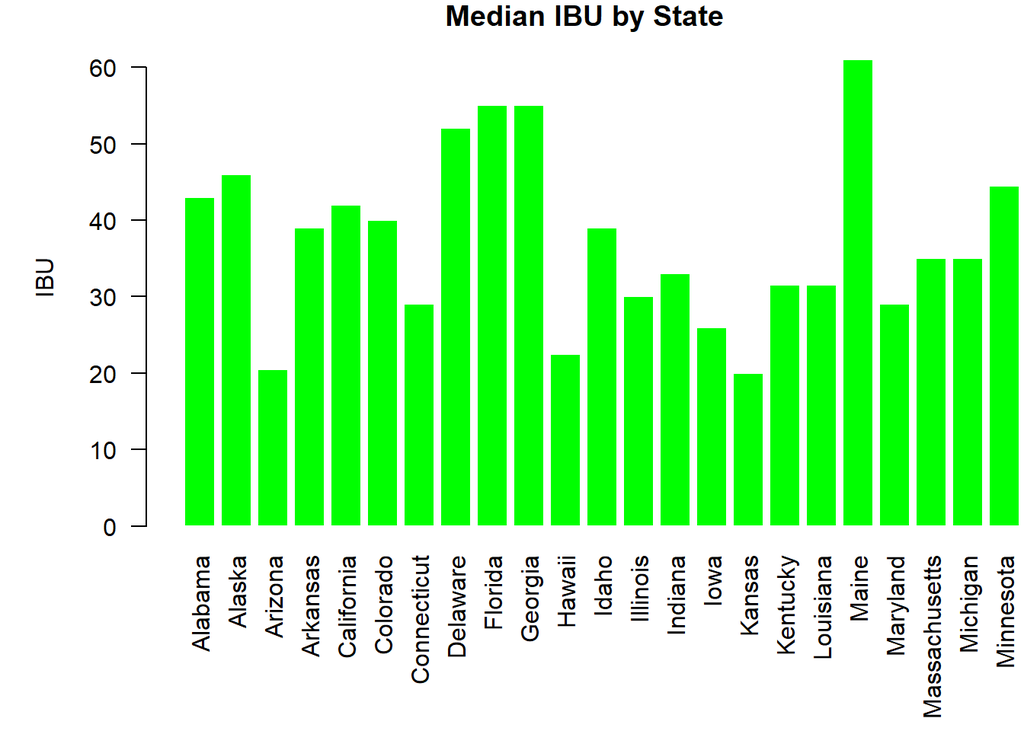

```r
#
# Plot a bar chart for ABV and IBU to compare all the states. It is better to prepare a table for the bar chart functions of the
# values we want to see.
# 1. Convert the data frame to a table for use in barplot
# 2. Since we have 51 entries in the table, split them and display in two bar charts for better look
#
library(data.table)
library(ggplot2)

ibu.table <- setDT(states.medians[, c(1, 3)])

par(mar=c(7, 5, 1, 0))
barplot(ibu.table$IBU[1:27] , border=F , names.arg=ibu.table$StateName[1:27], las=2, ylim=c(0,65), xlim=c(0, 40), width=1.5, main="Median IBU by State", col="green", ylab="IBU")
```

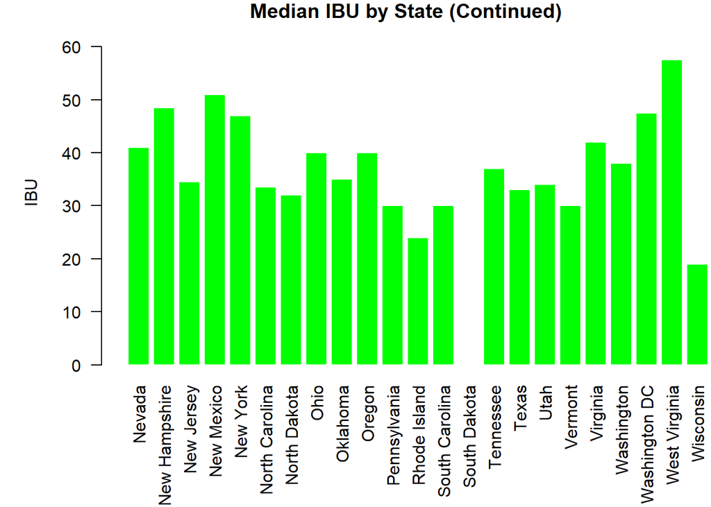

```r
barplot(ibu.table$IBU[28:51] , border=F , names.arg=ibu.table$StateName[28:51], las=2, ylim=c(0,65), xlim=c(0, 40), width=1.5, main="Median IBU by State (Continued)", col="green", ylab="IBU")
```

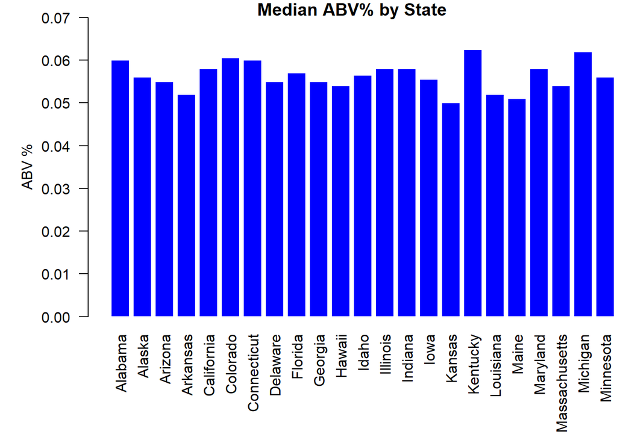

```r
abvp.table <- setDT(states.medians[, c(1, 2)])

barplot(abvp.table$ABV[1:27] , border=F , names.arg=ibu.table$StateName[1:27], las=2, ylim=c(0,0.07), xlim=c(0, 40), width=1.5, main="Median ABV% by State", col="blue", ylab="ABV %")
```

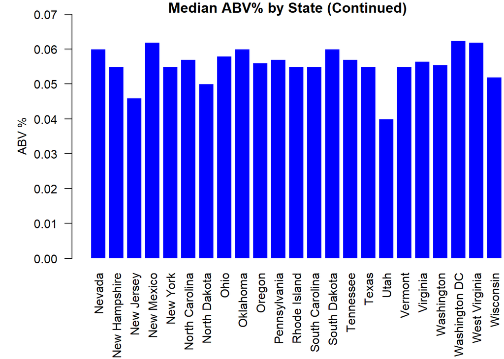

```r
barplot(abvp.table$ABV[28:51] , border=F , names.arg=ibu.table$StateName[28:51], las=2, ylim=c(0,0.07), xlim=c(0, 40), width=1.5, main="Median ABV% by State (Continued)", col="blue", ylab="ABV %")
```

$~$

Comparing the bar charts for the Alcohol By Volume (ABV) and International Bitterness Units (IBU), there is more variations in the medians for IBU among the states compared the variations of the medians for ABV.

### Question: 5. Which state has the maximum alcoholic (ABV) beer? Which state has the most bitter (IBU) beer?

AS part of the study, the team wanted to do more analysis on the characteristics of the beers produced by each state. Especially, they wanted to find out which state produced the beer with the most alchohol content and which state produced the most bitter beer.

**State with the beer that has the maximum ABV**

```r
#
# Get the state with the maximum ABV beer
#
max.abv <- subset(Beers.Breweries, ABV == max(Beers.Breweries$ABV, na.rm = T))
max.abv$ABVP <- paste(round(100*max.abv$ABV, 2), "%", sep="")
kable(max.abv[,c("StateName", "Beer", "ABVP")])
```

|  | StateName | Beer | ABVP |
| --- | --- | --- | --- |
| 375 | Colorado | Lee Hill Series Vol. 5 - Belgian Style Quadrupel Ale | 12.8% |
| $~$ |  |  |  |

**State with the beer that has the maximum bitterness**

```r
#
# Get the state with the most bitter beer
#
max.ibu <- subset(Beers.Breweries, IBU == max(Beers.Breweries$IBU, na.rm = T))
kable(max.ibu[,c("StateName", "Beer", "IBU")])
```

|  | StateName | Beer | IBU |
| --- | --- | --- | --- |
| 1857 | Oregon | Bitter Bitch Imperial IPA | 138 |

The study team had several smart R programmers. They found an alternative way of arriving at the same result :)

```r
max(Beers$ABV,na.rm = TRUE)
```

```
## [1] 0.128
```

```r
#min(Beers$ABV,na.rm = TRUE)

max(Beers$IBU,na.rm = TRUE)
```

```
## [1] 138
```

```r
#min(Beers$IBU,na.rm = TRUE)

#names(Beers)
#names(Breweries)
#Beers$Beer_ID
#Beers$Brewery_id
#Breweries$Brew_ID
### Hence based on the vector comparison the coloumn names Brewery_ID and Brew_ID are the common coloumns where the data frame merge or join is done

library(sqldf)
sqldf("SELECT MAX(ABV)from Beers")
```

```
##   MAX(ABV)
## 1    0.128
```

```r
sqldf("SELECT Name, Brewery_id FROM Beers WHERE ABV=0.128")
```

```
##                                                   Name Brewery_id
## 1 Lee Hill Series Vol. 5 - Belgian Style Quadrupel Ale         52
```

```r
sqldf("SELECT State FROM Breweries WHERE Brew_id=52")
```

```
##   State
## 1    CO
```

```r
## or we can use nested SQL indexing
sqldf("SELECT State FROM Breweries WHERE Brew_id=(SELECT Brewery_id FROM Beers WHERE ABV=(SELECT MAX(ABV)from Beers))")
```

```
##   State
## 1    CO
```

```r
## Hence the state with higher alcohol beer is Colorado

## To calculate the state with the state with the most bitter beer
max(Beers$IBU,na.rm = TRUE)
```

```
## [1] 138
```

```r
library(sqldf)
sqldf("SELECT MAX(IBU)from Beers")
```

```
##   MAX(IBU)
## 1      138
```

```r
sqldf("SELECT Name, Brewery_id FROM Beers WHERE IBU=138")
```

```
##                        Name Brewery_id
## 1 Bitter Bitch Imperial IPA        375
```

```r
sqldf("SELECT State FROM Breweries WHERE Brew_id=375")
```

```
##   State
## 1    OR
```

```r
## or we can use nested SQL indexing
sqldf("SELECT State FROM Breweries WHERE Brew_id=(SELECT Brewery_id FROM Beers WHERE IBU=(SELECT MAX(IBU)from Beers))")
```

```
##   State
## 1    OR
```

```r
## Hence based on the analysis Oregon has the most bitter Beer
```

$~$

### Question: 6. Summary statistics for the ABV variable

One of the goals of the study group is to find more information about the alchohol by volume charateristic of all the beers that are sold in all the states. The team leveraged the built-in functions in R language to highlight the various aspects of the ABV characteristics.

The group found out some interesting statistics about the ABV content of beers sold in all the states combined. The following tbale shows the various summary statistics along with the values.

```r
library(pastecs)
#stat.desc(Beers$ABV,BASIC=F) -Selwyn (Removed BASIC=F as it was giving an error "Unused argument")
ss <- stat.desc(Beers$ABV)
names(ss) <- c("Number of Values", "Number of Null values", "Number of NAs", "Minimum", "Maximum", "Range", "Sum", "Median", "Mean", "Standard Error", "95% Confidence Interval", "Variance", "Standard Deviation", "Coefficient of Variance")
kable(ss, caption="Summary Statistics for Alcohol by Volume", col.names = "Value")
```

Summary Statistics for Alcohol by Volume

|  | Value |
| --- | --- |
| Number of Values | 2348.0000000 |
| Number of Null values | 0.0000000 |
| Number of NAs | 62.0000000 |
| Minimum | 0.0010000 |
| Maximum | 0.1280000 |
| Range | 0.1270000 |
| Sum | 140.3480000 |
| Median | 0.0560000 |
| Mean | 0.0597734 |
| Standard Error | 0.0002795 |
| 95% Confidence Interval | 0.0005480 |
| Variance | 0.0001834 |
| Standard Deviation | 0.0135417 |
| Coefficient of Variance | 0.2265511 |
| $~$ |  |

### Question: 7. Is there an apparent relationship between the bitterness of the beer and its alcoholic content? Draw a scatter plot.

Finally, the team was asked to find out if there is any relationship that exists between the bitterness of the beer and its alcohol content.

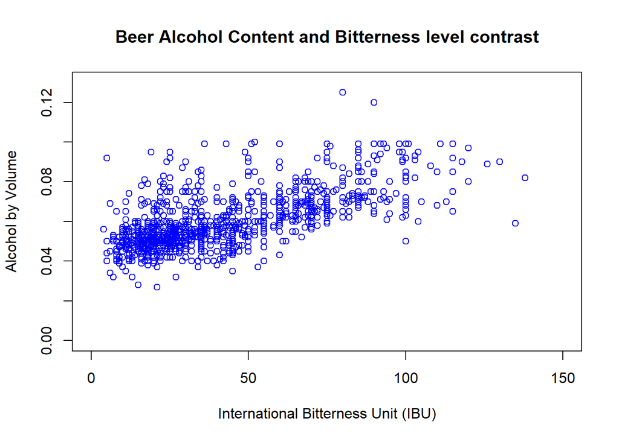

```r
library(scatterplot3d) # Selwyn - Added library

#
# Scatter plots using the various R libraries
#

plot(Beers$IBU, Beers$ABV, main="Beer Alcohol Content and Bitterness level contrast", col="blue", xlim=c(0,150), ylim = c(0,0.13), xlab = "International Bitterness Unit (IBU)", ylab = "Alcohol by Volume")
```

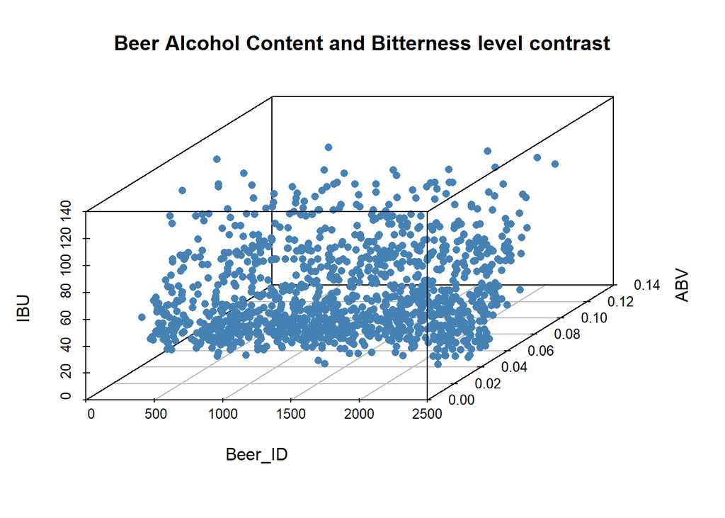

```r
scatterplot3d(Beers$Beer_ID, Beers$ABV,Beers$IBU,main="Beer Alcohol Content and Bitterness level contrast",xlab = "Beer_ID", xlim =c(0,2500),ylab = "ABV",ylim=c(0,0.13),zlab = "IBU " ,angle = 55,pch = 16, color="steelblue")
```

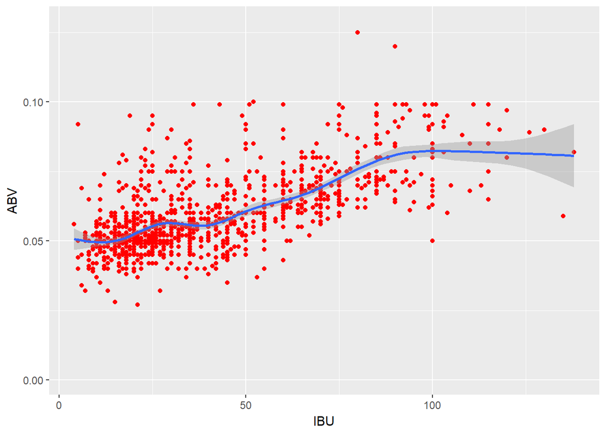

```r
p <- ggplot(Beers.Breweries, aes(IBU, ABV))
p + geom_point(na.rm = TRUE, colour="red") + geom_smooth()
```

$~$

Based on the scatter plots, we can see a slight postive relationship between the bitterness of the beer and the alcohol content. Even though the relationship is not direct, there is a slight trend of increasing bitterness leading to increasing alcohol content.

```r
#
# Generate codebook for the Beers and Breweries data structures
#
library(dataMaid)

attr(Beers, "labels") <- "The table contains the data collected about the beers that are brewed in the United States."
attr(Beers$Name, "shortDescription") <- "Name of the beer"
attr(Beers$Beer_ID, "shortDescription") <- "Unique identifier of the beer"
attr(Beers$ABV, "shortDescription") <- "Alcohol by volume of the beer"
attr(Beers$IBU, "shortDescription") <- "International Bitterness Units of the beer"
attr(Beers$Brewery_id, "shortDescription") <- "Unique identifier of the brewery that brewed the beer"
attr(Beers$Style, "shortDescription") <- "Style of the beer"
attr(Beers$Ounces, "shortDescription") <- "Ounces of beer"
#makeCodebook(Beers, reportTitle = "Table for beers brewed in the United States of America.")


attr(Breweries, "labels") <- "The table contains the data collected about the breweries in the United States."
attr(Breweries$Name, "shortDescription") <- "Name of the brewery"
attr(Breweries$Brew_ID, "shortDescription") <- "Unique identifier of the brewery"
attr(Breweries$City, "shortDescription") <- "City in which the brewery is located"
attr(Breweries$State, "shortDescription") <- "State in which the brewery is located"
#makeCodebook(Breweries, reportTitle = "Table for breweries in the United States of America.")
```